# FIT Kit Returns: Data Audit & EDA

Pre (2019-2021) vs post (2022-2023) text-reminder period

October 14, 2026

# 1. What the data is

The raw workbook (`01_data/raw/crc_raw.xlsx`) has **one row per patient** (2092 patients) with up to eight kit “slots” spread across columns, followed by a second block of “2022/23” columns and a set of spreadsheet-computed summaries.

```r
overview <- tibble(
  Measure = c("Patients", "Kits", "Kits: pre (2019-2021)", "Kits: post (2022-2023)",
              "Patients with kits in both periods", "Patients with pre kits only", "Patients with post kits only",
              "Dispense date range", "Latest return date in file"),
  Value = c(nrow(patients), nrow(kits), sum(kits$post == 0), sum(kits$post == 1),
            sum(patients$periods_observed == "Both"), sum(patients$periods_observed == "Pre only"),
            sum(patients$periods_observed == "Post only"),
            paste(format(min(kits$dispense_date)), "to", format(max(kits$dispense_date))),
            format(max(kits$return_date, na.rm = TRUE)))
)
kable(overview)
```

| Measure | Value |
| --- | --- |
| Patients | 2092 |
| Kits | 4302 |
| Kits: pre (2019-2021) | 1742 |
| Kits: post (2022-2023) | 2560 |
| Patients with kits in both periods | 876 |
| Patients with pre kits only | 148 |
| Patients with post kits only | 1068 |
| Dispense date range | 2019-01-02 to 2023-12-29 |
| Latest return date in file | 2024-06-05 |

**Clean tables** (in `01_data/clean/`, `.rds` keeps factor levels, `.csv` for portability):

| Table | Grain | Use |
| --- | --- | --- |
| `kits` | one row per kit (4302) | **Primary.** Bernoulli GLMM: `returned ~ post + ... + (1 \| patient_id)` |
| `patient_period` | patient × period (2968) | Binomial form: `cbind(n_returned, n_sent - n_returned)` |
| `patients` | one row per patient | Demographics and descriptives |

# 2. Audit findings & cleaning decisions

```r
audit %>% filter(area != "final") %>%
  rename(Area = area, Check = check, N = n, `Action taken` = action) %>%
  kable()
```

| Area | Check | N | Action taken |
| --- | --- | --- | --- |
| structure | rows in raw file | 2092 | one row per patient |
| structure | duplicate patientid | 0 | none expected |
| kits | kit records in slots 1-8 | 4305 | source of truth |
| kits | kit records missing dispense date | 0 | none expected |
| kits | lowercase ‘y’ in Returned | 1 | uppercased to Y |
| kits | return dates corrected (typo / text) | 7 | corrected; see corrections.csv |
| kits | return dates unrecoverable (UNK / before dispense) | 4 | set NA; returned status kept as Y |
| kits | Returned = N but return date present | 1 | recoded to Y (2022/23 copy agrees) |
| kits | Returned flag missing | 0 | none expected |
| kits | Returned = Y but no return date (after fixes) | 4 | kept as returned; days_to_return NA |
| kits | distinct raw Result spellings | 13 | normalised to 4 levels |
| kits | same-day kit pairs | 5 | inspected |
| kits | same-day blank duplicate removed | 3 | dropped (one returned record kept) |
| kits | kits with days_to_return > 365 | 2 | kept; flagged via returned_90d = 0 |
| kits | non-returned kits re-issued within 30 d | 9 | kept; flagged reissued_next_30d |
| kits | latest return date in file (extraction proxy) | 2024-06-05 | used for days_followup |
| crosscheck | post kits matched in 2022/23 block | 2548 | agree |
| crosscheck | post kits only in slots 1-8 | 7 | 2022/23 copy is incomplete |
| crosscheck | kits only in 2022/23 block | 0 | none expected (copy, not extra kits) |
| crosscheck | post kits with disagreeing fields | 6 | slots 1-8 kept unless shown wrong (see corrections) |
| patients | sex missing (patientsex) | 0 | complete; gender-identity columns not used |
| patients | text consent missing | 40 | level ‘Unknown’ |
| patients | text consent = No | 117 | potential comparison group (no reminders) |
| patients | employment missing | 203 | level ‘Unknown’ (sheet had coded these as unemployed) |
| patients | marital status missing/UNKNOWN | 39 | level ‘Unknown’ |
| patients | language missing | 3 | level ‘Unknown’ |
| patients | language ‘SPN/OTH’ | 1 | mapped to Other |
| patients | race/ethnicity differs from sheet’s adjusted column | 17 | re-derived consistently; see race_eth_recode.csv |
| patients | family size outside 1-8 | 0 | none |
| crosscheck | patients where sheet’s kit totals differ from rebuilt | 10 | rebuilt counts used; sheet summary columns dropped |
| eligibility | kits dispensed at age < 45 | 211 | kept; flagged age_in_45_75 = 0 |
| eligibility | kits dispensed at age >= 76 | 35 | kept; flagged age_in_45_75 = 0 |
| patients | patients with kits in both periods | 876 | within-patient pre/post contrast |
| patients | patients with pre-period kits only | 148 | NA |
| patients | patients with post-period kits only | 1068 | NA |

**Return-date corrections** (all listed in `03_output/audit/corrections.csv`):

```r
read_csv("03_output/audit/corrections.csv", show_col_types = FALSE) %>%
  rename(`Patient` = patient_id, Slot = slot, `Corrected date` = fixed_return_date, Reason = reason) %>%
  kable()
```

| Patient | Slot | Corrected date | Reason |
| --- | --- | --- | --- |
| 23460 | 1 | 2021-11-22 | typed as ‘11/22/221’; dispensed 2021-11-09 |
| 23083 | 1 | 2021-12-02 | typed as ‘12/2/221’; dispensed 2021-11-17 |
| 15120 | 2 | 2021-11-16 | typed as ‘11/16/221’; dispensed 2021-10-06 |
| 17633 | 4 | 2022-06-24 | stored as text ‘6/24/2022’ |
| 14467 | 1 | 2021-12-09 | recorded 1921-12-09 (century typo); dispensed 2021-09-14 |
| 21702 | 2 | 2022-07-13 | recorded 2002-07-13 (year typo); dispensed 2022-06-29 |
| 11984 | 2 | 2024-01-09 | recorded 2023-01-09, before 2023-12-29 dispense; 2022/23 block has 2024-01-09 |
| 23225 | 1 | NA | recorded 2021-07-14, before 2021-08-12 dispense; no recoverable date |
| 25967 | 1 | NA | ‘UNK’; 2022/23 copy holds 1964-04-03 (invalid) |
| 19132 | 4 | NA | ‘UNK’ |
| 15458 | 4 | NA | ‘UNK’ |

**Other decisions worth knowing about:**

- **Outcome** = kit returned (Y/N, as recorded). Spelling variants of `Returned` and `Result` were normalised; results map to Negative / Positive / Inadequate (TNP, “no result”) / Unknown.
- **Duplicate kits.** Three patients had the same kit entered twice on one dispense date (one returned record plus one blank “N” record). The blank record was dropped. Two other same-day pairs were both returned with different return dates and results, so they were kept as two kits.
- **Employment.** The sheet’s derived `Employed` columns coded the 203 patients with *missing* employment as unemployed. Here they are a separate `Unknown` level.
- **Race/ethnicity** was re-derived with one rule: Hispanic ethnicity first, then race. The sheet’s `Race/ethnicity adjusted` applied this inconsistently; for example, Mexican + White was coded “White” for 6 patients and “Hispanic” for 59. Seventeen patients changed category. See `race_eth_recode.csv`.
- **Sex** uses `patientsex`, which is complete. The gender-identity and sex-at-birth columns are sparse and were not used.
- **Missing categorical values** are kept as an explicit `Unknown` level rather than dropping rows. Whether to model `Unknown` as its own level or drop those patients is left for the modelling step.
- **Age** is computed at each kit’s dispense date, so it varies over time within a patient. `age_c10` = (age − 55)/10.
- **Not dropped, only flagged:** 246 kits given outside age 45-75 (`age_in_45_75`), 2 returns after more than 365 days, and 9 unreturned kits that were re-issued within 30 days (`reissued_next_30d`).
- **The spreadsheet’s summary columns** (total kits, ever returned, average time to return, etc.) were dropped and rebuilt from the kit records. Ten patients’ sheet totals disagreed with the kit records, mostly because of the duplicates above (`sheet_totals_mismatch.csv`).

# 3. Who is in the data

```r
demo_vars <- c("sex", "race_eth", "language", "text_consent", "employment", "relationship")
demo <- bind_rows(lapply(demo_vars, function(v) {
  kits %>% distinct(patient_id, period, level = .data[[v]]) %>%
    count(period, level) %>% group_by(period) %>% mutate(p = n / sum(n)) %>% ungroup() %>%
    mutate(variable = v)
})) %>%
  mutate(cell = sprintf("%d (%.0f%%)", n, 100 * p)) %>%
  select(variable, level, period, cell) %>%
  pivot_wider(names_from = period, values_from = cell, values_fill = "0")
kable(demo, col.names = c("Variable", "Level", "Patients with pre kits", "Patients with post kits"))
```

| Variable | Level | Patients with pre kits | Patients with post kits |
| --- | --- | --- | --- |
| sex | Female | 586 (57%) | 1078 (55%) |
| sex | Male | 438 (43%) | 866 (45%) |
| race_eth | Hispanic/Latino | 775 (76%) | 1496 (77%) |
| race_eth | White | 185 (18%) | 320 (16%) |
| race_eth | Black | 14 (1%) | 24 (1%) |
| race_eth | Asian | 22 (2%) | 45 (2%) |
| race_eth | Other | 15 (1%) | 36 (2%) |
| race_eth | Unknown | 13 (1%) | 23 (1%) |
| language | Spanish | 801 (78%) | 1515 (78%) |
| language | Polish | 159 (16%) | 272 (14%) |
| language | English | 20 (2%) | 109 (6%) |
| language | Other | 42 (4%) | 46 (2%) |
| language | Unknown | 2 (0%) | 2 (0%) |
| text_consent | Yes | 965 (94%) | 1801 (93%) |
| text_consent | No | 43 (4%) | 106 (5%) |
| text_consent | Unknown | 16 (2%) | 37 (2%) |
| employment | Full-time | 324 (32%) | 587 (30%) |
| employment | Part-time | 209 (20%) | 381 (20%) |
| employment | Seasonal/Temporary | 127 (12%) | 192 (10%) |
| employment | Other | 35 (3%) | 89 (5%) |
| employment | Unemployed | 276 (27%) | 502 (26%) |
| employment | Unknown | 53 (5%) | 193 (10%) |
| relationship | Not partnered | 453 (44%) | 867 (45%) |
| relationship | Partnered | 568 (55%) | 1040 (53%) |
| relationship | Unknown | 3 (0%) | 37 (2%) |

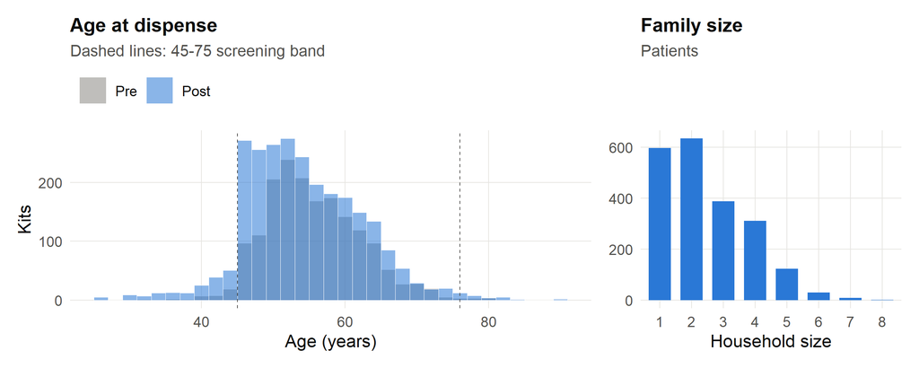

```r
p_age <- ggplot(kits, aes(age_at_dispense, fill = period)) +
  geom_histogram(binwidth = 2, boundary = 45, position = "identity", alpha = 0.55, colour = "white", linewidth = 0.2) +
  geom_vline(xintercept = c(45, 76), linetype = "dashed", colour = col_ink2, linewidth = 0.3) +
  scale_fill_manual(values = period_cols) +
  labs(title = "Age at dispense", subtitle = "Dashed lines: 45-75 screening band", x = "Age (years)", y = "Kits")
p_fam <- patients %>% count(family_size) %>%
  ggplot(aes(factor(family_size), n)) + geom_col(fill = col_post, width = 0.7) +
  labs(title = "Family size", subtitle = "Patients", x = "Household size", y = NULL)
p_age + p_fam + plot_layout(widths = c(2, 1))
```

The sample is mostly Hispanic/Latino and Spanish-speaking. Black, Asian, Other and Unknown race/ethnicity together make up about 7% of patients. **Language and race/ethnicity are nearly redundant** (Spanish ↔︎ Hispanic, Polish ↔︎ White; section 8), so putting both in one model will make their effects hard to separate. Kits given at ages under 45 are concentrated in 2022-2023, which fits the guideline age dropping from 50 to 45 in 2021.

# 4. The headline: return rate over time

```r
hl <- rate_tbl(kits, period)
kable(hl %>% transmute(Period = period, Kits = n, Returned = x,
                       `Return rate` = pct(rate), `95% CI` = paste0(pct(lo), " – ", pct(hi))))
```

| Period | Kits | Returned | Return rate | 95% CI |
| --- | --- | --- | --- | --- |
| Pre | 1742 | 1351 | 77.6% | 75.5% – 79.5% |
| Post | 2560 | 2143 | 83.7% | 82.2% – 85.1% |

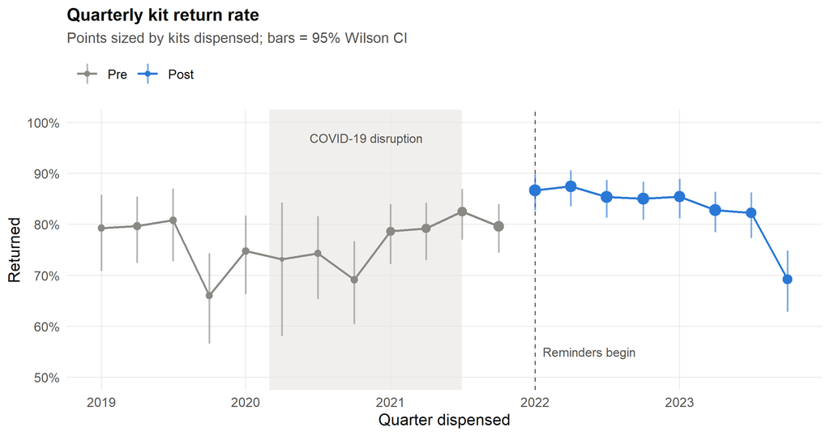

```r
q <- kits %>%
  mutate(qtr = as.Date(cut(dispense_date, "quarter"))) %>%
  rate_tbl(qtr, period)
ggplot(q, aes(qtr, rate, colour = period)) +
  annotate("rect", xmin = as.Date("2020-03-01"), xmax = as.Date("2021-06-30"), ymin = -Inf, ymax = Inf,
           fill = col_grid, alpha = 0.6) +
  annotate("text", x = as.Date("2020-11-01"), y = 0.97, label = "COVID-19 disruption", size = 3, colour = col_ink2) +
  geom_vline(xintercept = as.Date("2022-01-01"), linetype = "dashed", colour = col_ink2, linewidth = 0.4) +
  annotate("text", x = as.Date("2022-01-20"), y = 0.55, label = "Reminders begin", hjust = 0, size = 3, colour = col_ink2) +
  geom_linerange(aes(ymin = lo, ymax = hi), linewidth = 0.6, alpha = 0.6) +
  geom_line(linewidth = 0.7) +
  geom_point(aes(size = n)) +
  scale_colour_manual(values = period_cols) +
  scale_size_area(max_size = 3.5, guide = "none") +
  scale_y_continuous(labels = label_percent(), limits = c(0.5, 1)) +
  labs(title = "Quarterly kit return rate", subtitle = "Points sized by kits dispensed; bars = 95% Wilson CI",
       x = "Quarter dispensed", y = "Returned")
```

```r
kable(rate_tbl(kits, dispense_year) %>%
        transmute(Year = dispense_year, Kits = n, `Return rate` = pct(rate), `95% CI` = paste0(pct(lo), " – ", pct(hi))))
```

| Year | Kits | Return rate | 95% CI |
| --- | --- | --- | --- |
| 2019 | 475 | 76.8% | 72.8% – 80.4% |
| 2020 | 389 | 72.8% | 68.1% – 76.9% |
| 2021 | 878 | 80.1% | 77.3% – 82.6% |
| 2022 | 1394 | 86.2% | 84.2% – 87.9% |
| 2023 | 1166 | 80.8% | 78.4% – 82.9% |

**What this shows for the model:**

- The raw pre→post difference is about 6 points. But the pre-period rate drops in 2020 (COVID) and is already recovering in 2021, and 2023 falls back below 2022. A plain `post` indicator will soak up secular trend and COVID recovery along with any reminder effect. Consider calendar-time terms (`time_yrs`, an interrupted-time-series slope change) or a COVID-period indicator.
- The decline at the end of 2023 is examined in section 7: censoring is not the main explanation.

# 5. Return rate by demographic group, pre vs post

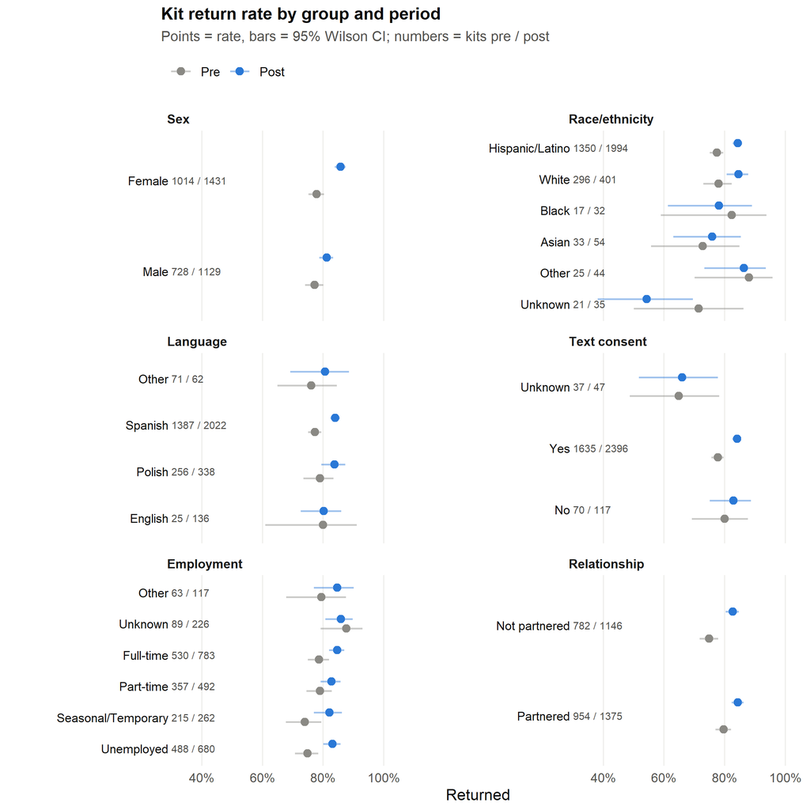

```r
grp_vars <- c(Sex = "sex", `Race/ethnicity` = "race_eth", Language = "language",
              `Text consent` = "text_consent", Employment = "employment", Relationship = "relationship")
sg <- bind_rows(lapply(names(grp_vars), function(lbl) {
  rate_tbl(kits %>% mutate(level = .data[[grp_vars[[lbl]]]]), level, period) %>% mutate(var = lbl)
})) %>%
  mutate(var = factor(var, levels = names(grp_vars))) %>%
  group_by(var, level) %>% filter(min(n) >= 10) %>% ungroup()   # drops language Unknown (3 patients)

# explicit vertical offset: pre slightly below, post slightly above each level's row
sg <- sg %>%
  group_by(var) %>% mutate(row = as.numeric(fct_rev(factor(level)))) %>% ungroup() %>%
  mutate(y = row + if_else(period == "Pre", -0.15, 0.15))
sg_n <- sg %>% group_by(var, level, row) %>%
  summarise(lab = paste0(n[period == "Pre"], " / ", n[period == "Post"]), .groups = "drop")

ggplot(sg, aes(rate, y, colour = period)) +
  geom_segment(aes(x = lo, xend = hi, yend = y), linewidth = 0.6, alpha = 0.45) +
  geom_point(size = 2.4) +
  geom_text(data = sg_n, aes(x = 0.30, y = row, label = lab), inherit.aes = FALSE,
            colour = col_ink2, size = 2.6, hjust = 0) +
  facet_wrap(~ var, ncol = 2, scales = "free_y") +
  scale_y_continuous(breaks = function(l) seq_len(floor(max(l))),
                     labels = NULL, expand = expansion(add = 0.4)) +
  geom_text(data = sg_n, aes(x = 0.29, y = row, label = level), inherit.aes = FALSE,
            colour = col_ink, size = 3, hjust = 1) +
  coord_cartesian(xlim = c(0.30, 1), clip = "off") +
  scale_colour_manual(values = period_cols) +
  scale_x_continuous(labels = label_percent(), breaks = seq(0.4, 1, 0.2)) +
  labs(title = "Kit return rate by group and period",
       subtitle = "Points = rate, bars = 95% Wilson CI; numbers = kits pre / post",
       x = "Returned", y = NULL) +
  theme(plot.margin = margin(5, 10, 5, 115), panel.grid.major.y = element_blank(),
        panel.spacing.x = unit(120, "pt"))
```

- Most groups rise from pre to post by similar amounts. Small groups (Black, Asian, Other, Unknown, Other language) have wide intervals and should be partially pooled (random effects) or collapsed rather than given their own fixed slopes.
- **Text consent = No is an important comparison group.** Those 117 patients presumably could not receive reminders. If their return rate also rose after 2022, the rise is secular rather than caused by the reminders. A `post × text_consent` interaction is the closest thing to a difference-in-differences contrast the data supports. Check with the clinic that non-consenting patients really received no messages.

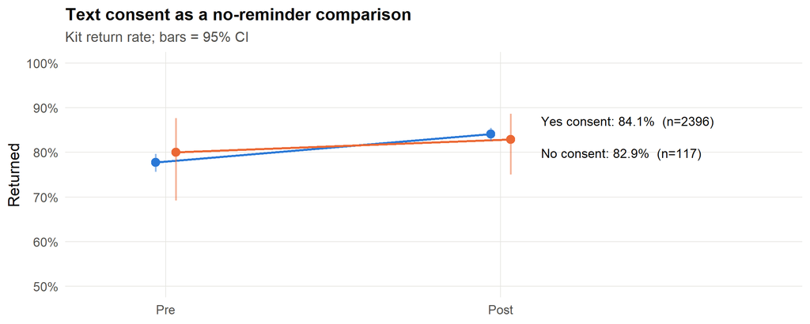

```r
cd <- rate_tbl(kits %>% filter(text_consent != "Unknown"), text_consent, period)
dodge <- position_dodge(width = 0.12)
ggplot(cd, aes(period, rate, colour = text_consent, group = text_consent)) +
  geom_line(linewidth = 0.7, position = dodge) +
  geom_linerange(aes(ymin = lo, ymax = hi), linewidth = 0.6, alpha = 0.5, position = dodge) +
  geom_point(size = 2.6, position = dodge) +
  geom_text(data = cd %>% filter(period == "Post") %>%
              mutate(label_y = rate + if_else(text_consent == "Yes", 0.03, -0.03)),
            aes(y = label_y, label = paste0(text_consent, " consent: ", pct(rate), "  (n=", n, ")")),
            hjust = 0, nudge_x = 0.12, size = 3.2, colour = col_ink, show.legend = FALSE) +
  scale_colour_manual(values = c(Yes = col_post, No = "#eb6834")) +
  scale_y_continuous(labels = label_percent(), limits = c(0.5, 1)) +
  scale_x_discrete(expand = expansion(add = c(0.3, 0.9))) +
  labs(title = "Text consent as a no-reminder comparison", subtitle = "Kit return rate; bars = 95% CI",
       x = NULL, y = "Returned") +
  theme(legend.position = "none")
```

```r
kable(cd %>% transmute(`Text consent` = text_consent, Period = period, Kits = n, `Return rate` = pct(rate),
                       `95% CI` = paste0(pct(lo), " – ", pct(hi))))
```

| Text consent | Period | Kits | Return rate | 95% CI |
| --- | --- | --- | --- | --- |
| Yes | Pre | 1635 | 77.7% | 75.7% – 79.7% |
| Yes | Post | 2396 | 84.1% | 82.6% – 85.5% |
| No | Pre | 70 | 80.0% | 69.2% – 87.7% |
| No | Post | 117 | 82.9% | 75.1% – 88.7% |

# 6. Within-patient structure (why a mixed model)

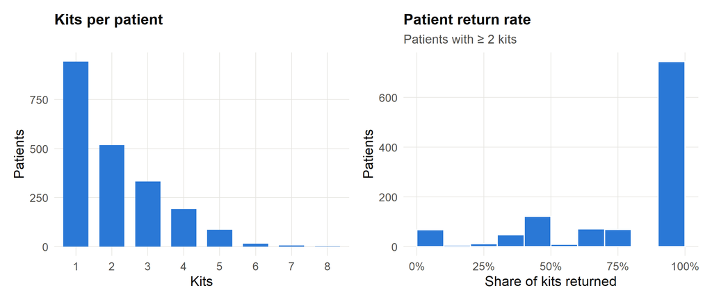

```r
kpp <- patients %>% count(n_kits) %>%
  ggplot(aes(factor(n_kits), n)) + geom_col(fill = col_post, width = 0.7) +
  labs(title = "Kits per patient", x = "Kits", y = "Patients")
prate <- patients %>% filter(n_kits >= 2) %>% mutate(r = n_returned / n_kits) %>%
  ggplot(aes(r)) + geom_histogram(binwidth = 0.1, boundary = 0, fill = col_post, colour = "white") +
  scale_x_continuous(labels = label_percent()) +
  labs(title = "Patient return rate", subtitle = "Patients with ≥ 2 kits", x = "Share of kits returned", y = "Patients")
kpp + prate
```

```r
# Simple one-way ANOVA ICC on the binary outcome (descriptive, not a model)
multi <- kits %>% group_by(patient_id) %>% filter(n() >= 2) %>% ungroup()
a <- anova(lm(returned ~ factor(patient_id), data = multi))
k0 <- with(multi %>% count(patient_id), (sum(n) - sum(n^2) / sum(n)) / (n_distinct(patient_id) - 1))
icc <- (a$`Mean Sq`[1] - a$`Mean Sq`[2]) / (a$`Mean Sq`[1] + (k0 - 1) * a$`Mean Sq`[2])

hist_tbl <- kits %>% filter(n_prior_kits > 0) %>%
  mutate(history = cut(prior_return_rate, c(-Inf, 0, 0.99, Inf), labels = c("None returned", "Some returned", "All returned"))) %>%
  rate_tbl(history)
```

- Most patients with several kits return all of them or none. The descriptive ICC of the binary outcome among patients with ≥ 2 kits is about **0.31**. Kits from the same patient are not independent, so a patient random intercept `(1 | patient_id)` is necessary.
- Prior behaviour strongly predicts the next kit: return rate is 89.2% when every earlier kit was returned and 48.9% when none were. The random intercept already captures this. **Do not also add `prior_return_rate` as a covariate** next to the random intercept: it is a lagged outcome and would partly absorb the reminder effect, because post kits are later in each patient’s sequence.
- Only 876 patients contribute kits in **both** periods. For the other 1216, the pre/post contrast is between different people, so patient covariates do more of the work there.

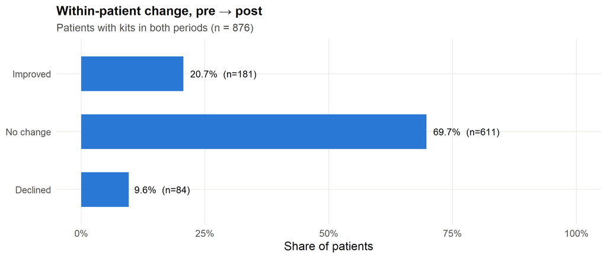

```r
paired <- pp %>% filter(periods_observed == "Both") %>%
  select(patient_id, period, return_rate) %>%
  pivot_wider(names_from = period, values_from = return_rate) %>%
  mutate(change = case_when(Post > Pre ~ "Improved", Post < Pre ~ "Declined", TRUE ~ "No change")) %>%
  count(change) %>% mutate(p = n / sum(n), change = factor(change, c("Declined", "No change", "Improved")))
ggplot(paired, aes(p, change)) + geom_col(fill = col_post, width = 0.6) +
  geom_text(aes(label = paste0(pct(p), "  (n=", n, ")")), hjust = -0.1, size = 3.2, colour = col_ink) +
  scale_x_continuous(labels = label_percent(), limits = c(0, 1)) +
  labs(title = "Within-patient change, pre → post", subtitle = "Patients with kits in both periods (n = 876)",
       x = "Share of patients", y = NULL)
```

# 7. Time to return & censoring

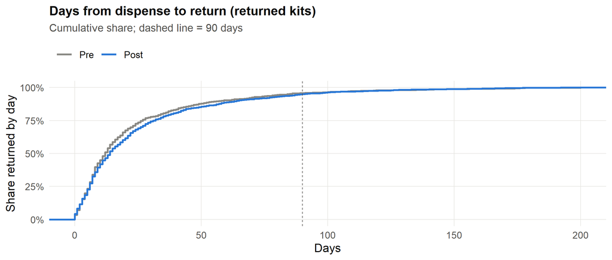

```r
ttr <- kits %>% filter(returned == 1, !is.na(days_to_return))
ggplot(ttr, aes(days_to_return, colour = period)) +
  stat_ecdf(linewidth = 0.8) +
  geom_vline(xintercept = 90, linetype = "dashed", colour = col_ink2, linewidth = 0.3) +
  scale_colour_manual(values = period_cols) +
  scale_x_continuous(limits = c(0, 200)) +
  scale_y_continuous(labels = label_percent()) +
  labs(title = "Days from dispense to return (returned kits)", subtitle = "Cumulative share; dashed line = 90 days",
       x = "Days", y = "Share returned by day")
```

```r
kable(ttr %>% group_by(Period = period) %>%
        summarise(`Returned kits` = n(), `Median days` = median(days_to_return),
                  `75th pct` = quantile(days_to_return, 0.75), `Within 90 d` = pct(mean(days_to_return <= 90))))
```

| Period | Returned kits | Median days | 75th pct | Within 90 d |
| --- | --- | --- | --- | --- |
| Pre | 1350 | 12 | 27 | 95.5% |
| Post | 2140 | 14 | 32 | 94.3% |

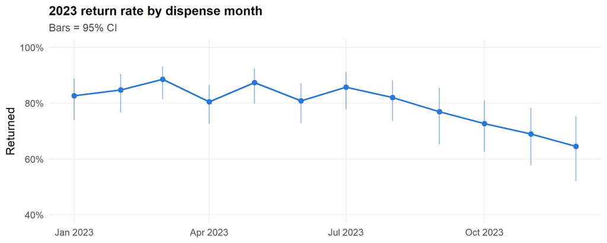

```r
tail_m <- kits %>% filter(dispense_date >= as.Date("2023-01-01")) %>%
  mutate(month = as.Date(cut(dispense_date, "month"))) %>% rate_tbl(month)
ggplot(tail_m, aes(month, rate)) +
  geom_linerange(aes(ymin = lo, ymax = hi), colour = col_post, alpha = 0.5) +
  geom_line(colour = col_post, linewidth = 0.7) + geom_point(colour = col_post, size = 2) +
  scale_y_continuous(labels = label_percent(), limits = c(0.4, 1)) +
  labs(title = "2023 return rate by dispense month", subtitle = "Bars = 95% CI", x = NULL, y = "Returned")
```

- Returns are fast: the median is about two weeks and about 95% arrive within 90 days. Post-period returns are **not** faster; if anything they are a little slower (median 14 vs 12 days). Any reminder effect looks like *more* returns, not *quicker* ones, possibly because reminders bring in late returners who would otherwise never have returned.

```r
q4 <- kits %>% mutate(q = if_else(dispense_month >= 10, "Q4 (Oct-Dec)", "Q1-Q3")) %>%
  rate_tbl(dispense_year, q) %>%
  transmute(dispense_year, q, cell = sprintf("%s (n=%d)", pct(rate), n)) %>%
  pivot_wider(names_from = q, values_from = cell)
kable(q4, col.names = c("Year", "Q1-Q3", "Q4 (Oct-Dec)"), caption = "Return rate by dispense quarter, by year")
```

Return rate by dispense quarter, by year

| Year | Q1-Q3 | Q4 (Oct-Dec) |
| --- | --- | --- |
| 2019 | 79.9% (n=369) | 66.0% (n=106) |
| 2020 | 74.3% (n=269) | 69.2% (n=120) |
| 2021 | 80.3% (n=603) | 79.6% (n=275) |
| 2022 | 86.5% (n=1046) | 85.1% (n=348) |
| 2023 | 83.5% (n=942) | 69.2% (n=224) |

- The latest return in the file is 2024-06-05, so even December 2023 kits had more than 5 months of follow-up. That captures almost all eventual returns, so **right-censoring cannot explain the drop to about 65% in late 2023**.
- **Q4 is low in 3 of 5 years** (2019, 2020, 2023), but not in 2021 or 2022, so seasonality explains the late-2023 dip only partly at best. Adding a Q4 or month-of-year term to the model, plus a sensitivity analysis excluding Q4 2023, is reasonable. It is still worth asking the clinic whether anything changed operationally in late 2023.
- `returned_90d` is provided as an alternative outcome with equal follow-up for every kit.

# 8. Covariate overlap

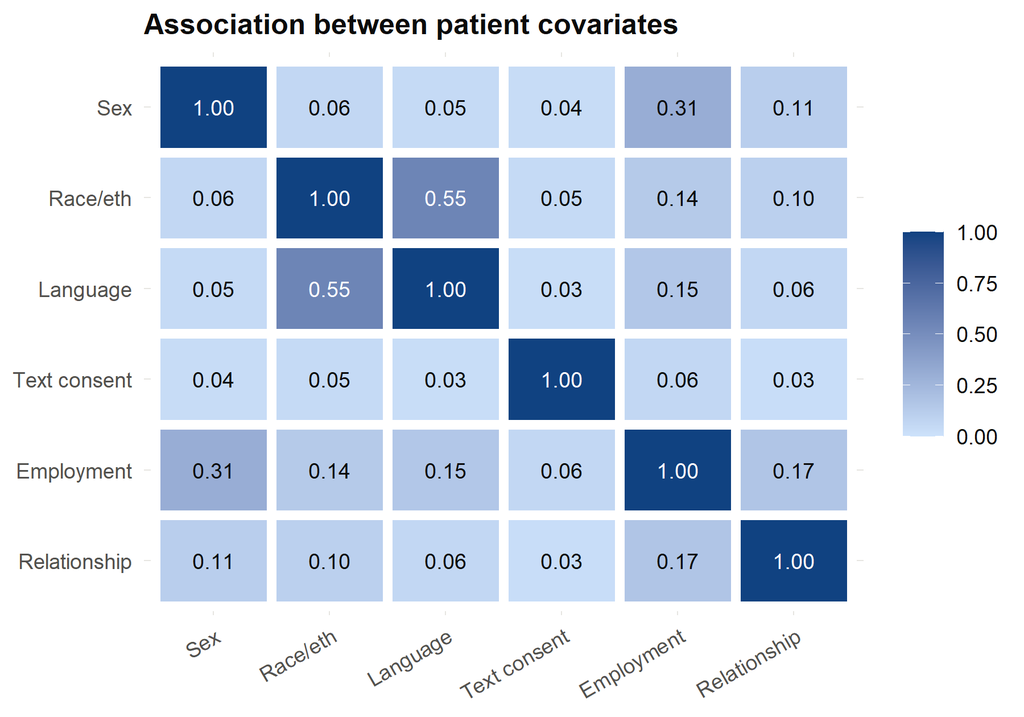

```r
cramers_v <- function(x, y) {
  t <- table(x, y); chi <- suppressWarnings(chisq.test(t, correct = FALSE)$statistic)
  as.numeric(sqrt(chi / (sum(t) * (min(dim(t)) - 1))))
}
cv_vars <- c(sex = "Sex", race_eth = "Race/eth", language = "Language", text_consent = "Text consent",
             employment = "Employment", relationship = "Relationship")
cv <- expand_grid(a = names(cv_vars), b = names(cv_vars)) %>%
  rowwise() %>% mutate(v = cramers_v(patients[[a]], patients[[b]])) %>% ungroup() %>%
  mutate(a = factor(cv_vars[a], levels = cv_vars), b = factor(cv_vars[b], levels = rev(cv_vars)))
ggplot(cv, aes(a, b, fill = v)) +
  geom_tile(colour = "white", linewidth = 2) +
  geom_text(aes(label = sprintf("%.2f", v), colour = v > 0.5), size = 3.2) +
  scale_colour_manual(values = c(`TRUE` = "white", `FALSE` = col_ink), guide = "none") +
  scale_fill_gradient(low = "#cde2fb", high = "#104281", limits = c(0, 1), name = "Cramér's V") +
  labs(title = "Association between patient covariates", x = NULL, y = NULL) +
  theme(panel.grid = element_blank(), axis.text.x = element_text(angle = 30, hjust = 1), legend.position = "right")
```

```r
kable(table(patients$language, patients$race_eth), caption = "Language × race/ethnicity (patients)")
```

Language × race/ethnicity (patients)

|  | Hispanic/Latino | White | Black | Asian | Other | Unknown |
| --- | --- | --- | --- | --- | --- | --- |
| Spanish | 1569 | 18 | 2 | 9 | 8 | 15 |
| Polish | 2 | 282 | 0 | 1 | 11 | 3 |
| English | 19 | 33 | 24 | 22 | 13 | 5 |
| Other | 2 | 21 | 3 | 16 | 7 | 4 |
| Unknown | 3 | 0 | 0 | 0 | 0 | 0 |

Language and race/ethnicity are strongly associated (Cramér’s V ≈ 0.55). Pick one as the main grouping, or use the `lang_concordant` contrast (reminder available in the patient’s language vs. “Other” language) for the language question. Sex and employment are moderately associated (V ≈ 0.31), which is workable but worth checking for unstable estimates. All other pairs are weak (V < 0.2).

# 9. Notes for the modelling step

1. **Use `kits.rds` as the model table.** Model `returned` as Bernoulli with `(1 | patient_id)`. Use `patient_period.rds` only if you want the binomial form; it averages age within each period.
2. **Separate the reminder effect from time.** Add calendar-time terms (`time_yrs`, possibly a slope change at 2022, or a COVID-period indicator) and a seasonal term (Q4 / `dispense_month`). Use `text_consent` as a no-reminder comparison through a `post × text_consent` interaction.
3. **Sparse groups:** pool race/ethnicity and language groups with random effects or collapse them. Don’t give `Unknown` levels their own random slopes.
4. **Covariate choices:** use `age_c10` (time-varying), `sex`, `family_size_c`, `relationship`, and `employment` (six levels) or `employed`. Avoid having `language` and `race_eth` both as fixed effects.
5. **Sensitivity analyses:** restrict to `age_in_45_75 == 1`; exclude Q4 2023; use `returned_90d` as the outcome; restrict to patients with kits in both periods.
6. **Selection caveat:** every patient has an order chart date between 2021-11 and 2023-11, so the cohort was defined by being active during the reminder era. Pre-period kits are therefore only from patients who stayed with the clinic. Data cleaning cannot fix this, but it bounds how far the pre/post comparison generalises.

```
## Rendered with R4.4.2
```